# Risk Factor Analysis

## Outcome Variable

**Outcome Variable:** sstunted

## Predictor Variables

**Intervention Variable:** hfoodsec

**Adjustment Set:**

unadjusted

## Stratifying Variables

The analysis was stratified on these variable(s):

- agecat
- studyid

The following strata were considered:

- agecat: 12 months, studyid: ki0047075b-MAL-ED
- agecat: 12 months, studyid: ki1017093-NIH-Birth
- agecat: 12 months, studyid: ki1017093c-NIH-Crypto
- agecat: 12 months, studyid: ki1113344-GMS-Nepal
- agecat: 18 months, studyid: ki0047075b-MAL-ED
- agecat: 18 months, studyid: ki1017093-NIH-Birth
- agecat: 18 months, studyid: ki1017093c-NIH-Crypto
- agecat: 18 months, studyid: ki1113344-GMS-Nepal
- agecat: 24 months, studyid: ki0047075b-MAL-ED
- agecat: 24 months, studyid: ki1017093-NIH-Birth
- agecat: 24 months, studyid: ki1017093c-NIH-Crypto
- agecat: 24 months, studyid: ki1113344-GMS-Nepal
- agecat: 3 months, studyid: ki0047075b-MAL-ED
- agecat: 3 months, studyid: ki1017093-NIH-Birth
- agecat: 3 months, studyid: ki1017093c-NIH-Crypto
- agecat: 3 months, studyid: ki1113344-GMS-Nepal
- agecat: 6 months, studyid: ki0047075b-MAL-ED
- agecat: 6 months, studyid: ki1017093-NIH-Birth
- agecat: 6 months, studyid: ki1017093c-NIH-Crypto
- agecat: 6 months, studyid: ki1113344-GMS-Nepal
- agecat: 9 months, studyid: ki0047075b-MAL-ED
- agecat: 9 months, studyid: ki1017093-NIH-Birth
- agecat: 9 months, studyid: ki1017093c-NIH-Crypto
- agecat: 9 months, studyid: ki1113344-GMS-Nepal
- agecat: Birth, studyid: ki0047075b-MAL-ED
- agecat: Birth, studyid: ki1017093-NIH-Birth
- agecat: Birth, studyid: ki1017093c-NIH-Crypto

### Dropped Strata

Some strata were dropped due to rare outcomes:

- agecat: Birth, studyid: ki0047075b-MAL-ED
- agecat: Birth, studyid: ki1017093-NIH-Birth
- agecat: Birth, studyid: ki1017093c-NIH-Crypto
- agecat: 3 months, studyid: ki0047075b-MAL-ED
- agecat: 3 months, studyid: ki1017093-NIH-Birth
- agecat: 3 months, studyid: ki1017093c-NIH-Crypto
- agecat: 3 months, studyid: ki1113344-GMS-Nepal
- agecat: 6 months, studyid: ki0047075b-MAL-ED
- agecat: 6 months, studyid: ki1017093-NIH-Birth
- agecat: 6 months, studyid: ki1017093c-NIH-Crypto
- agecat: 6 months, studyid: ki1113344-GMS-Nepal
- agecat: 9 months, studyid: ki0047075b-MAL-ED
- agecat: 9 months, studyid: ki1017093-NIH-Birth
- agecat: 9 months, studyid: ki1017093c-NIH-Crypto
- agecat: 9 months, studyid: ki1113344-GMS-Nepal
- agecat: 12 months, studyid: ki0047075b-MAL-ED
- agecat: 12 months, studyid: ki1017093-NIH-Birth
- agecat: 12 months, studyid: ki1017093c-NIH-Crypto
- agecat: 12 months, studyid: ki1113344-GMS-Nepal
- agecat: 18 months, studyid: ki1017093-NIH-Birth
- agecat: 18 months, studyid: ki1017093c-NIH-Crypto
- agecat: 18 months, studyid: ki1113344-GMS-Nepal
- agecat: 24 months, studyid: ki1017093-NIH-Birth
- agecat: 24 months, studyid: ki1017093c-NIH-Crypto
- agecat: 24 months, studyid: ki1113344-GMS-Nepal

## Methods Detail

We’re interested in the causal parameters $E[Y_a]$ for all values of $a \in \mathcal{A}$. These parameters represent the mean outcome if, possibly contrary to fact, we intervened to set all units to have $A=a$. Under the randomization and positivity assumptions, these are identified by the statistical parameters $\psi_a=E_W[E_{Y|A,W}(Y|A=a,W)]$. In addition, we’re interested in the mean of $Y$, $E[Y]$ under no intervention (the observed mean). We will estimate these parameters by using SuperLearner to fit the relevant likelihood factors – $E_{Y|A,W}(Y|A=a,W)$ and $p(A=a|W)$, and then updating our likelihood fit using a joint TMLE.

For unadjusted analyses ($W=\{\}$), initial likelihoods were estimated using Lrnr_glm to estimate the simple $E(Y|A)$ and Lrnr_mean to estimate $p(A)$. For adjusted analyses, a small library containing Lrnr_glmnet, Lrnr_xgboost, and Lrnr_mean was used.

Having estimated these parameters, we will then use the delta method to estimate relative risks and attributable risks relative to a prespecified baseline level of $A$.

# Results Detail

## Results Plots

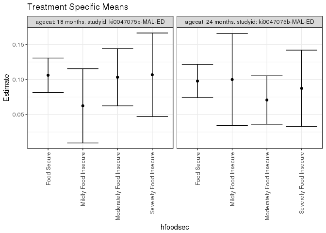

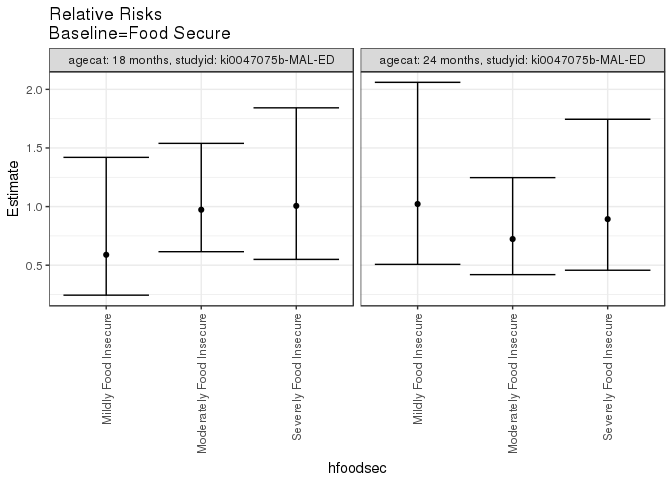

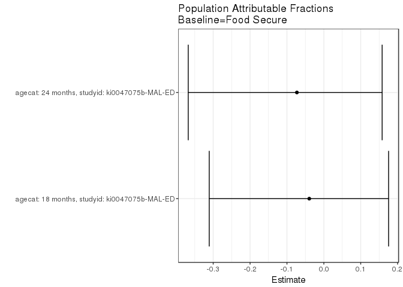

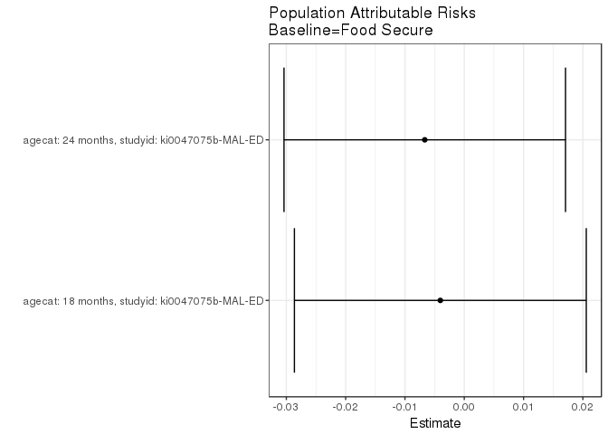

## Data Summary

| agecat | studyid | A | n | nA | nAY0 | nAY1 |
| --- | --- | --- | --- | --- | --- | --- |
| Birth | ki0047075b-MAL-ED | Food Secure | 863 | 521 | 513 | 8 |
| Birth | ki0047075b-MAL-ED | Mildly Food Insecure | 863 | 68 | 67 | 1 |
| Birth | ki0047075b-MAL-ED | Moderately Food Insecure | 863 | 184 | 177 | 7 |
| Birth | ki0047075b-MAL-ED | Severely Food Insecure | 863 | 90 | 88 | 2 |
| Birth | ki1017093-NIH-Birth | Food Secure | 28 | 3 | 3 | 0 |
| Birth | ki1017093-NIH-Birth | Mildly Food Insecure | 28 | 21 | 21 | 0 |
| Birth | ki1017093-NIH-Birth | Moderately Food Insecure | 28 | 4 | 4 | 0 |
| Birth | ki1017093-NIH-Birth | Severely Food Insecure | 28 | 0 | 0 | 0 |
| Birth | ki1017093c-NIH-Crypto | Food Secure | 27 | 14 | 14 | 0 |
| Birth | ki1017093c-NIH-Crypto | Mildly Food Insecure | 27 | 9 | 9 | 0 |
| Birth | ki1017093c-NIH-Crypto | Moderately Food Insecure | 27 | 2 | 2 | 0 |
| Birth | ki1017093c-NIH-Crypto | Severely Food Insecure | 27 | 2 | 1 | 1 |
| Birth | ki1113344-GMS-Nepal | Food Secure | 0 | 0 | 0 | 0 |
| Birth | ki1113344-GMS-Nepal | Mildly Food Insecure | 0 | 0 | 0 | 0 |
| Birth | ki1113344-GMS-Nepal | Moderately Food Insecure | 0 | 0 | 0 | 0 |
| Birth | ki1113344-GMS-Nepal | Severely Food Insecure | 0 | 0 | 0 | 0 |
| 3 months | ki0047075b-MAL-ED | Food Secure | 1006 | 604 | 586 | 18 |
| 3 months | ki0047075b-MAL-ED | Mildly Food Insecure | 1006 | 83 | 80 | 3 |
| 3 months | ki0047075b-MAL-ED | Moderately Food Insecure | 1006 | 214 | 209 | 5 |
| 3 months | ki0047075b-MAL-ED | Severely Food Insecure | 1006 | 105 | 100 | 5 |
| 3 months | ki1017093-NIH-Birth | Food Secure | 570 | 84 | 82 | 2 |
| 3 months | ki1017093-NIH-Birth | Mildly Food Insecure | 570 | 446 | 419 | 27 |
| 3 months | ki1017093-NIH-Birth | Moderately Food Insecure | 570 | 35 | 31 | 4 |
| 3 months | ki1017093-NIH-Birth | Severely Food Insecure | 570 | 5 | 5 | 0 |
| 3 months | ki1017093c-NIH-Crypto | Food Secure | 728 | 432 | 418 | 14 |
| 3 months | ki1017093c-NIH-Crypto | Mildly Food Insecure | 728 | 210 | 199 | 11 |
| 3 months | ki1017093c-NIH-Crypto | Moderately Food Insecure | 728 | 62 | 57 | 5 |
| 3 months | ki1017093c-NIH-Crypto | Severely Food Insecure | 728 | 24 | 21 | 3 |
| 3 months | ki1113344-GMS-Nepal | Food Secure | 553 | 399 | 387 | 12 |
| 3 months | ki1113344-GMS-Nepal | Mildly Food Insecure | 553 | 79 | 75 | 4 |

[output cut: 82 more lines]

## Results Table

### Parameter: TSM

| agecat | studyid | intervention_level | baseline_level | estimate | ci_lower | ci_upper |
| --- | --- | --- | --- | --- | --- | --- |
| 18 months | ki0047075b-MAL-ED | Food Secure | NA | 0.1061360 | 0.0815394 | 0.1307325 |
| 18 months | ki0047075b-MAL-ED | Mildly Food Insecure | NA | 0.0625000 | 0.0094304 | 0.1155696 |
| 18 months | ki0047075b-MAL-ED | Moderately Food Insecure | NA | 0.1032864 | 0.0623957 | 0.1441771 |
| 18 months | ki0047075b-MAL-ED | Severely Food Insecure | NA | 0.1067961 | 0.0471201 | 0.1664722 |
| 24 months | ki0047075b-MAL-ED | Food Secure | NA | 0.0978441 | 0.0741186 | 0.1215696 |
| 24 months | ki0047075b-MAL-ED | Mildly Food Insecure | NA | 0.1000000 | 0.0342278 | 0.1657722 |
| 24 months | ki0047075b-MAL-ED | Moderately Food Insecure | NA | 0.0707547 | 0.0362212 | 0.1052882 |
| 24 months | ki0047075b-MAL-ED | Severely Food Insecure | NA | 0.0873786 | 0.0328160 | 0.1419412 |

### Parameter: E(Y)

| agecat | studyid | intervention_level | baseline_level | estimate | ci_lower | ci_upper |
| --- | --- | --- | --- | --- | --- | --- |
| 18 months | ki0047075b-MAL-ED | NA | NA | 0.1021021 | 0.1013733 | 0.1028309 |
| 24 months | ki0047075b-MAL-ED | NA | NA | 0.0911824 | 0.0904934 | 0.0918713 |

### Parameter: RR

| agecat | studyid | intervention_level | baseline_level | estimate | ci_lower | ci_upper |
| --- | --- | --- | --- | --- | --- | --- |
| 18 months | ki0047075b-MAL-ED | Mildly Food Insecure | Food Secure | 0.5888672 | 0.2442103 | 1.419943 |
| 18 months | ki0047075b-MAL-ED | Moderately Food Insecure | Food Secure | 0.9731514 | 0.6151110 | 1.539598 |
| 18 months | ki0047075b-MAL-ED | Severely Food Insecure | Food Secure | 1.0062197 | 0.5495065 | 1.842522 |
| 24 months | ki0047075b-MAL-ED | Mildly Food Insecure | Food Secure | 1.0220339 | 0.5070218 | 2.060174 |
| 24 months | ki0047075b-MAL-ED | Moderately Food Insecure | Food Secure | 0.7231372 | 0.4193095 | 1.247116 |
| 24 months | ki0047075b-MAL-ED | Severely Food Insecure | Food Secure | 0.8930393 | 0.4570367 | 1.744978 |

### Parameter: PAR

| agecat | studyid | intervention_level | baseline_level | estimate | ci_lower | ci_upper |
| --- | --- | --- | --- | --- | --- | --- |
| 18 months | ki0047075b-MAL-ED | Food Secure | NA | -0.0040339 | -0.0286412 | 0.0205734 |
| 24 months | ki0047075b-MAL-ED | Food Secure | NA | -0.0066617 | -0.0303972 | 0.0170737 |

### Parameter: PAF

| agecat | studyid | intervention_level | baseline_level | estimate | ci_lower | ci_upper |
| --- | --- | --- | --- | --- | --- | --- |
| 18 months | ki0047075b-MAL-ED | Food Secure | NA | -0.0395083 | -0.3107549 | 0.1756067 |
| 24 months | ki0047075b-MAL-ED | Food Secure | NA | -0.0730596 | -0.3676778 | 0.1580935 |